# Model Terbaik ARIMA

# ARIMA (5,1,13)

## Plot Residual

```r
Close.UNVRJK5113 = arima(diff1.log.AP, order = c(5,1,13))
```

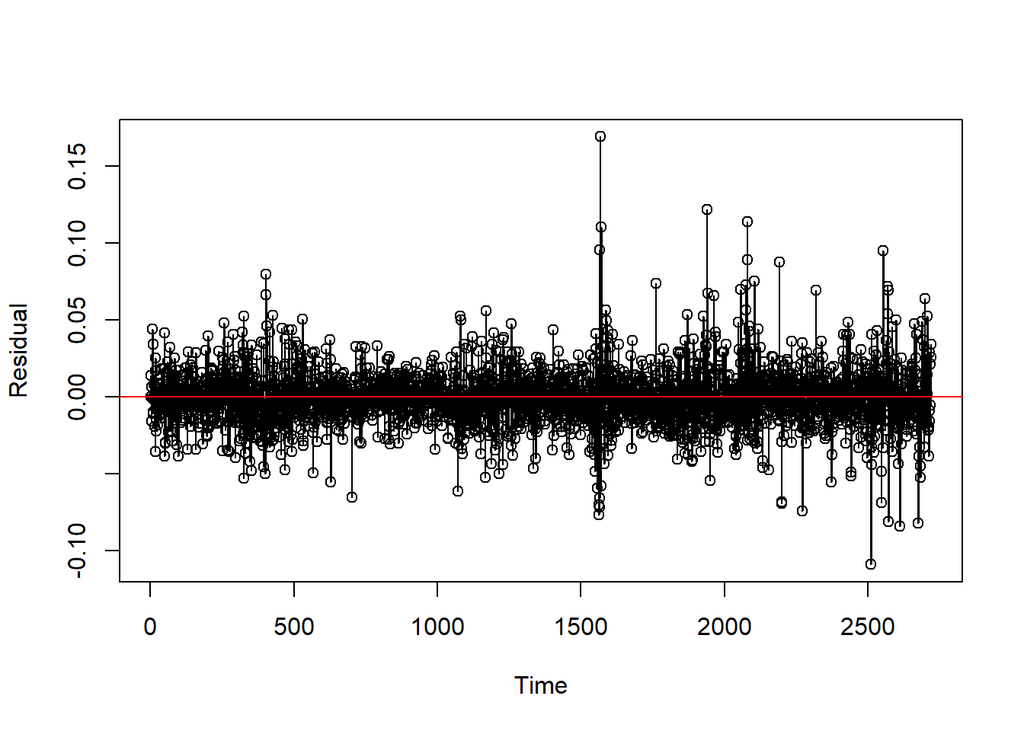

```r
Res.Close5113 = residuals(Close.UNVRJK5113)
plot(Res.Close5113, ylab = "Residual", type = "o")
abline(h=0, col = "red")
```

Pada output di atas terlihat plot residual yang mempermudah kita untuk melihat residual yang tidak wajar. Berdasarkan plot di atas terlihat bahwa tidak terdapat tren pada residual.

## Plot Kuantil Kenormalan

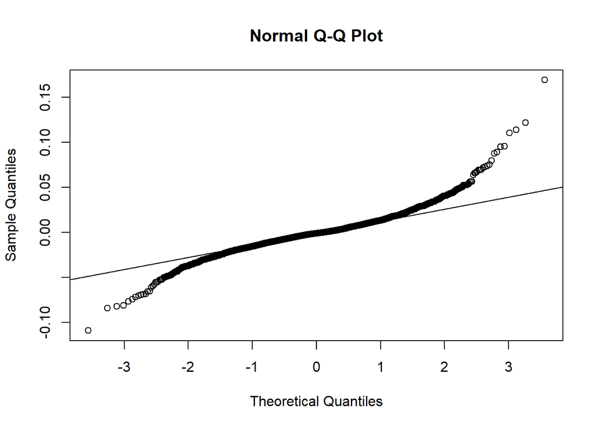

```r
qqnorm(Res.Close5113)
qqline(Res.Close5113)
```

Berdasarkan plot kuantil kenormalan terlihat bahwa beberapa titik berada di luar garis kuantil-kuantil.

## Uji Kolmogorov-Smirnov Test

```r
ks.test(Res.Close5113, "pnorm", mean=mean(Res.Close5113), sd=sd(Res.Close5113))
```

```
##
##  Asymptotic one-sample Kolmogorov-Smirnov test
##
## data:  Res.Close5113
## D = 0.074015, p-value = 2.334e-13
## alternative hypothesis: two-sided
```

Karena nilai p-value (2.334e-13) < α=5%, maka H0 ditolak. Artinya, dapat disimpulkan bahwa residual tidak mengikuti distribusi normal. Sehingga, asumsi normalitas tidak terpenuhi.

```r
kurtosis(Res.Close5113)
```

```
## [1] 9.925892
```

Nilai kurtosis residual (Res.Close) yang kamu dapatkan adalah 9.925892, yang jauh lebih besar dari 3. Ini berarti distribusi residualnya leptokurtic (lebih runcing dari distribusi normal), yang menunjukkan bahwa data memiliki lebih banyak outlier dibanding distribusi normal.

```r
skewness(Res.Close5113)  # Jika jauh dari 0, kemungkinan butuh sstd
```

```
## [1] 0.692754
```

## ACF Residual

Untuk memerika asumsi kebebasan derau (noise), kita bisa memeriksa fungsi autokorelasi sampel residual.

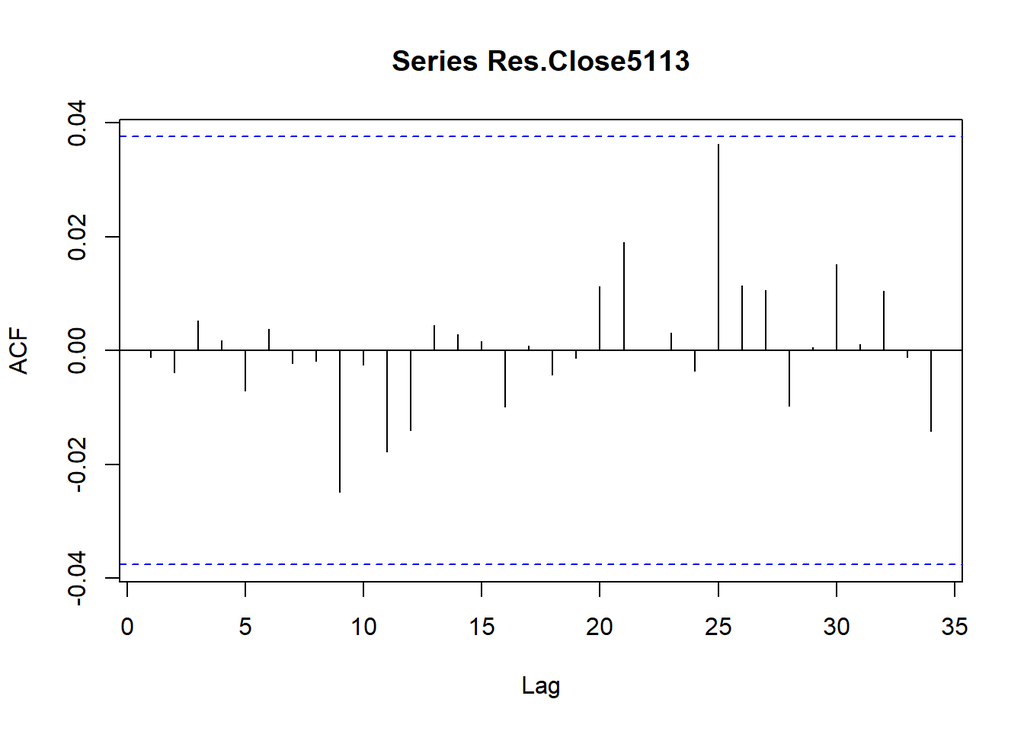

```r
acf(Res.Close5113)
```

Berdasarkan plot fungsi autokorelasi sampel terlihat bahwa tidak ada yang melewati batas garis putus-putus.

## Menghitung nilai Ljung-Box

```r
ljung_box5113 <- Box.test(Res.Close5113, lag = 25, type = "Ljung-Box")
ljung_box5113
```

```
##
##  Box-Ljung test
##
## data:  Res.Close5113
## X-squared = 8.881, df = 25, p-value = 0.9987
```

Berdasarkan analisis Box-Ljung test, dimana nilai P-value (0.9987) lebih besar dari α=5%. Jadi dapat disimpulkan bahwa residual tidak berautokorelasi. Sehingga, asumsi non-autokorelasi terpenuhi.

## LJung-Box Statistik

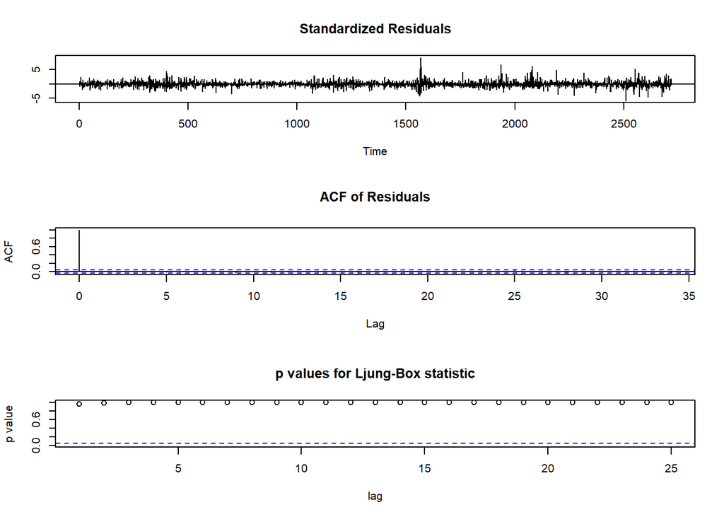

```r
tsdiag(Close.UNVRJK5113, gof.lag =25)
```

Berdasarkan plot Ljung-Box terlihat bahwa tidak ada p-value yang berada di bawah garis putus-putus (nilai 0.05).

# Uji LM

```r
# Uji ARCH-LM pada standardized residuals
ArchTest(Res.Close5113, lags = 10)
```

```
##
##  ARCH LM-test; Null hypothesis: no ARCH effects
##
## data:  Res.Close5113
## Chi-squared = 263.92, df = 10, p-value < 2.2e-16
```

Pengecekan efek arch dilakukan dengan arch.test terhadap Close dan didapatkan nilai p-value 2.2e-16 yang berarti < alpha (0,05). Hal tersebut berarti menolak Ho (tidak ada efek arch) yang menandakan terdapat ada efek arch pada ARIMA (5,1,13)

# Kesimpulan